# Shrinkage and Sharing power

Peter Ralph

23 November 2020 – Advanced Biological Statistics

# Simulation

## Wouldn’t it be nice if we knew the truth?

Let’s write down a procedure to simulate data that looks like the baseball data.

```r
batting$post_mean <- colMeans(param_samples$theta)
batting$fake_hits <- rbinom(nrow(batting),
                            size=batting$AtBats,
                            prob=batting$post_mean)
```

*Option 1:* By simulating draws from the posterior mean on $\theta$, we can check that our model is accurately describing the data. Here is the real data against data simulated under the posterior mean $\theta$ values. They look similar, which is good.

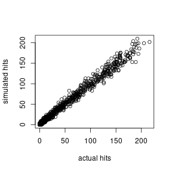

**But** if we want to know if we’re accurately estimating $\mu$ and $\kappa$, then we have to start with them, and *simulate* $\theta$.

```r
post_mean_mu <- colMeans(param_samples$mu)
post_mean_kappa <- colMeans(param_samples$kappa)
names(post_mean_mu) <- names(post_mean_kappa) <- levels(batting$PriPos)
batting$sim_theta <- rbeta(nrow(batting),
                           shape1=post_mean_mu[batting$PriPos] *
                                   post_mean_kappa[batting$PriPos],
                           shape2=(1-post_mean_mu[batting$PriPos]) *
                                   post_mean_kappa[batting$PriPos])
batting$sim_theta_hits <- rbinom(nrow(batting),
                                 size=batting$AtBats,
                                 prob=batting$sim_theta)
```

Fit the model to the *simulated* data:

```r
sim_fit <- sampling(pos_model, chains=3, iter=1000, control=list(max_treedepth=13),
                data=list(N=nrow(batting),
                          hits=batting$sim_theta_hits,
                          at_bats=batting$AtBats,
                          npos=nlevels(batting$PriPos),
                          position=as.numeric(batting$PriPos)))
```

Can we estimate $\mu$ and $\kappa$?

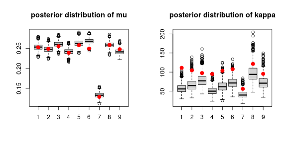

```r
sim_samples <- rstan::extract(sim_fit)
layout(t(1:2))
boxplot(sim_samples$mu, main="posterior distribution of mu")
points(1:9, post_mean_mu, col='red', pch=20, cex=2)
boxplot(sim_samples$kappa, main="posterior distribution of kappa")
points(1:9, post_mean_kappa, col='red', pch=20, cex=2)
```

## General questions with simulated data

1. Does my statistical inference method work?
2. Do the credible intervals contain the true value?

   (i.e., Is the method “well-calibrated”?)

   *They usually should.*
3. How wide are credible intervals, typically?

   This is (one kind of) **statistical power.**

# Sharing power // Shrinkage

## Example

Suppose that I have a large pot of coins that are all similar to each other. I flip each one ten times, and record the number of Heads. What is *each coin’s* probability of Heads?

- Treated *separately*, we would be very uncertain about each coin.
- Together, they should tell us very accurately what are *likely* values of $\theta$.
- This information can improve the estimate of each separate $\theta$.
- The more similar the coins are, the more information we gain.

By *shrinking* each estimate towards their *common* mean, we hope to gain *power*.

## Shrinkage and baseball

Some players were at bat very few times. How does the information about their position affect our inference about their batting averages?

```r
batting$post_med <- colMedians(param_samples$theta)
batting$post_Q1 <- colQuantiles(param_samples$theta, probs=0.25)
batting$post_Q3 <- colQuantiles(param_samples$theta, probs=0.75)
pos_means <- colMeans(param_samples$mu)
names(pos_means) <- levels(batting$PriPos)
pos_means
```

```
##     1st Base     2nd Base     3rd Base      Catcher Center Field   Left Field      Pitcher  Right Field    Shortstop
##    0.2526893    0.2489027    0.2553305    0.2388856    0.2579088    0.2495208    0.1289218    0.2586869    0.2478177
```

Pitchers had posterior mean $\mu$ of 0.1289218

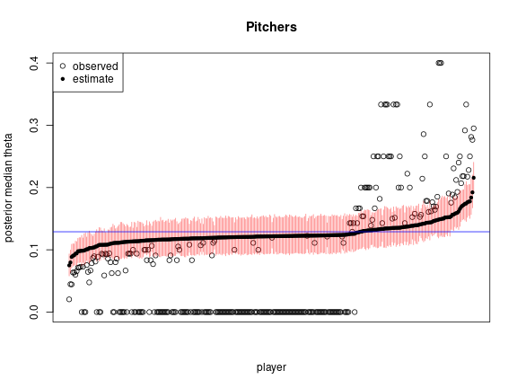

```r
with(subset(batting[order(batting$post_med),], PriPos=="Pitcher"), {
     plot(Hits / AtBats, main="Pitchers", xaxt='n', ylim=c(0, 0.4),
         xlab='player', ylab="posterior median theta");
     segments(x0=seq_along(Hits), y0=post_Q1, y1=post_Q3,
         col=adjustcolor('red',0.5));
     points(post_med, pch=20) })
abline(h=pos_means["Pitcher"], lwd=2, col=adjustcolor("blue", 0.5))
legend("topleft", pch=c(1,20), legend=c("observed", "estimate"))
```

Catchers had posterior mean $\mu$ of 0.2388856:

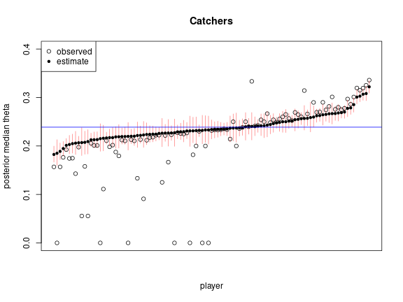

```r
with(subset(batting[order(batting$post_med),], PriPos=="Catcher"), {
     plot(Hits / AtBats, main="Catchers", xaxt='n', ylim=c(0, 0.4),
         xlab='player', ylab="posterior median theta");
     segments(x0=seq_along(Hits), y0=post_Q1, y1=post_Q3,
         col=adjustcolor('red',0.5));
     points(post_med, pch=20) })
abline(h=pos_means["Catcher"], lwd=2, col=adjustcolor("blue", 0.5))
legend("topleft", pch=c(1,20), legend=c("observed", "estimate"))
```

## Is shrinkage here a good idea?

- posterior mean $\theta_i$
- empirical batting average

How’d we do? Let’s look at the *true* values of $\theta$ (we know because we generated them) against the posterior means. Red lines are 95% credible intervals.

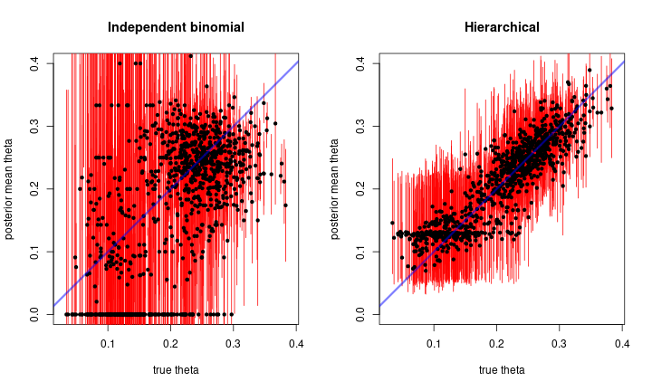

Did we do better?

The mean absolute difference between the *truth* and

- posterior mean: 0.0253747
- empirical batting average (hits/at bats): 0.0866087

// reveal.js plugins